# google app store graded project

**8. Convert the column "Reviews'' to numeric data type and check the presence of outliers in the column and handle the outliers using a transformation approach.(Hint: Use log transformation)**

```python
# the DataFrame is named as 'df'
# Convert the "Reviews" column to numeric data type using function "pd.to_numeric"errors='coerce' is used to handle non-numeric to convert into NAN them
df['Reviews'] = pd.to_numeric(df['Reviews'], errors='coerce')
#its use to displays the reviews from df
df['Reviews']
```

```
0           159
1           967
2         87510
3        215644
4           967
          ...
10834         7
10836        38
10837         4
10839       114
10840    398307
Name: Reviews, Length: 8892, dtype: int64
```

```python
#its to display the information of df which is of reviews dtype is int its converted
df.info()
```

```
<class 'pandas.core.frame.DataFrame'>
Int64Index: 8892 entries, 0 to 10840
Data columns (total 14 columns):
 #   Column           Non-Null Count  Dtype
---  ------           --------------  -----
 0   App              8892 non-null   object
 1   Category         8892 non-null   object
 2   Rating           8892 non-null   float64
 3   Reviews          8892 non-null   int64
 4   Size             8892 non-null   object
 5   Installs         8892 non-null   object
 6   Type             8892 non-null   object
 7   Price            8892 non-null   object
 8   Content Rating   8892 non-null   object
 9   Genres           8892 non-null   object
 10  Last Updated     8892 non-null   object
 11  Current Ver      8888 non-null   object
 12  Android Ver      8890 non-null   object
 13  Rating_category  8892 non-null   object
dtypes: float64(1), int64(1), object(12)
memory usage: 1.0+ MB
```

**the calculation of the quartiles (q1 and q3),the interquartile range(iqr), and the lower and upper bounds for outlier detection.then filter the rows where the 'Reviews' values fall below the lower bound or above the upper bound to identify the outliers**

```python
# Check for outliers in the "Reviews" column
Q1 = df['Reviews'].quantile(0.25)
Q3 = df['Reviews'].quantile(0.75)
IQR = Q3 - Q1
upper_bound = Q3 + 1.5 * IQR
lower_bound = Q1 - 1.5 * IQR

outliers = df[(df['Reviews'] > upper_bound) | (df['Reviews'] < lower_bound)]
print("Number of outliers:", len(outliers))
```

```
Number of outliers: 1555
```

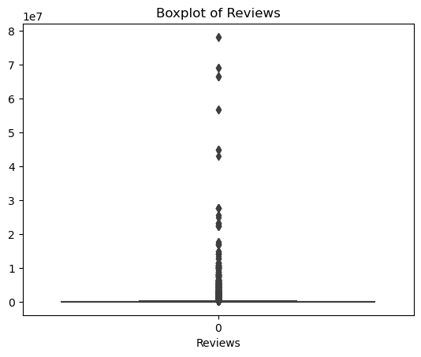

```python
#create a boxplot of the 'Reviews'column with automatic outlier detection
sns.boxplot(df['Reviews'])
#set the titles and labels
plt.title('Boxplot of Reviews')
plt.xlabel('Reviews')
#show the plot
plt.show()
```

```python
# Handle outliers using log transformation function for reviews
df['Reviews_transformed'] = np.log1p(df['Reviews'])
#it displays the df of reviews_transformed which is transformation of Reviews is displayed
df['Reviews_transformed']
```

```
0         5.075174
1         6.875232
2        11.379520
3        12.281389
4         6.875232
           ...
10834     2.079442
10836     3.663562
10837     1.609438
10839     4.744932
10840    12.894981
Name: Reviews_transformed, Length: 8892, dtype: float64
```

```python
# Display the updated DataFrame
print(df)
```

```
                                                     App             Category  \
0         Photo Editor & Candy Camera & Grid & ScrapBook       ART_AND_DESIGN
1                                    Coloring book moana       ART_AND_DESIGN
2      U Launcher Lite – FREE Live Cool Themes, Hide ...       ART_AND_DESIGN
3                                  Sketch - Draw & Paint       ART_AND_DESIGN
4                  Pixel Draw - Number Art Coloring Book       ART_AND_DESIGN
...                                                  ...                  ...
10834                                      FR Calculator               FAMILY
10836                                   Sya9a Maroc - FR               FAMILY
10837                   Fr. Mike Schmitz Audio Teachings               FAMILY
10839                      The SCP Foundation DB fr nn5n  BOOKS_AND_REFERENCE
10840      iHoroscope - 2018 Daily Horoscope & Astrology            LIFESTYLE

       Rating  Reviews                Size     Installs  Type Price  \
0         4.1      159                 19M      10,000+  Free     0
```

[output cut: 51 more lines]

```python
#displays the updated information of the dataframe
df.info()
```

```
<class 'pandas.core.frame.DataFrame'>
Int64Index: 8892 entries, 0 to 10840
Data columns (total 15 columns):
 #   Column               Non-Null Count  Dtype
---  ------               --------------  -----
 0   App                  8892 non-null   object
 1   Category             8892 non-null   object
 2   Rating               8892 non-null   float64
 3   Reviews              8892 non-null   int64
 4   Size                 8892 non-null   object
 5   Installs             8892 non-null   object
 6   Type                 8892 non-null   object
 7   Price                8892 non-null   object
 8   Content Rating       8892 non-null   object
 9   Genres               8892 non-null   object
 10  Last Updated         8892 non-null   object
 11  Current Ver          8888 non-null   object
 12  Android Ver          8890 non-null   object
 13  Rating_category      8892 non-null   object
 14  Reviews_transformed  8892 non-null   float64
dtypes: float64(2), int64(1), object(12)
memory usage: 1.3+ MB
```

**9. The column 'Size' contains alphanumeric values, treat the non numeric data and convert the column into suitable data type. (hint: Replace M with 1 million and K with 1 thousand, and drop the entries wheresize = 'Varies with device')**

```python
#it displays the first 5 rows
df.head()
```

|  | App | Category | Rating | Reviews | Size | Installs | Type | Price | Content Rating | Genres | Last Updated | Current Ver | Android Ver | Rating_category | Reviews_transformed |
| --- | --- | --- | --- | --- | --- | --- | --- | --- | --- | --- | --- | --- | --- | --- | --- |
| 0 | Photo Editor & Candy Camera & Grid & ScrapBook | ART_AND_DESIGN | 4.1 | 159 | 19M | 10,000+ | Free | 0 | Everyone | Art & Design | January 7, 2018 | 1.0.0 | 4.0.3 and up | High | 5.075174 |
| 1 | Coloring book moana | ART_AND_DESIGN | 3.9 | 967 | 14M | 500,000+ | Free | 0 | Everyone | Art & Design;Pretend Play | January 15, 2018 | 2.0.0 | 4.0.3 and up | High | 6.875232 |
| 2 | U Launcher Lite – FREE Live Cool Themes, Hide ... | ART_AND_DESIGN | 4.7 | 87510 | 8.7M | 5,000,000+ | Free | 0 | Everyone | Art & Design | August 1, 2018 | 1.2.4 | 4.0.3 and up | High | 11.379520 |
| 3 | Sketch - Draw & Paint | ART_AND_DESIGN | 4.5 | 215644 | 25M | 50,000,000+ | Free | 0 | Teen | Art & Design | June 8, 2018 | Varies with device | 4.2 and up | High | 12.281389 |
| 4 | Pixel Draw - Number Art Coloring Book | ART_AND_DESIGN | 4.3 | 967 | 2.8M | 100,000+ | Free | 0 | Everyone | Art & Design;Creativity | June 20, 2018 | 1.1 | 4.4 and up | High | 6.875232 |

```python
# Drop the entries where size='Varies with device'it as to drop the values
# 9. Treat the non-numeric values in the 'Size' column
df = df[df['Size'] != 'Varies with device']
#it displays the dataframe with updated dataframe
df
```

|  | App | Category | Rating | Reviews | Size | Installs | Type | Price | Content Rating | Genres | Last Updated | Current Ver | Android Ver | Rating_category | Reviews_transformed |
| --- | --- | --- | --- | --- | --- | --- | --- | --- | --- | --- | --- | --- | --- | --- | --- |
| 0 | Photo Editor & Candy Camera & Grid & ScrapBook | ART_AND_DESIGN | 4.1 | 159 | 19M | 10,000+ | Free | 0 | Everyone | Art & Design | January 7, 2018 | 1.0.0 | 4.0.3 and up | High | 5.075174 |
| 1 | Coloring book moana | ART_AND_DESIGN | 3.9 | 967 | 14M | 500,000+ | Free | 0 | Everyone | Art & Design;Pretend Play | January 15, 2018 | 2.0.0 | 4.0.3 and up | High | 6.875232 |
| 2 | U Launcher Lite – FREE Live Cool Themes, Hide ... | ART_AND_DESIGN | 4.7 | 87510 | 8.7M | 5,000,000+ | Free | 0 | Everyone | Art & Design | August 1, 2018 | 1.2.4 | 4.0.3 and up | High | 11.379520 |
| 3 | Sketch - Draw & Paint | ART_AND_DESIGN | 4.5 | 215644 | 25M | 50,000,000+ | Free | 0 | Teen | Art & Design | June 8, 2018 | Varies with device | 4.2 and up | High | 12.281389 |
| 4 | Pixel Draw - Number Art Coloring Book | ART_AND_DESIGN | 4.3 | 967 | 2.8M | 100,000+ | Free | 0 | Everyone | Art & Design;Creativity | June 20, 2018 | 1.1 | 4.4 and up | High | 6.875232 |
| ... | ... | ... | ... | ... | ... | ... | ... | ... | ... | ... | ... | ... | ... | ... | ... |
| 10833 | Chemin (fr) | BOOKS_AND_REFERENCE | 4.8 | 44 | 619k | 1,000+ | Free | 0 | Everyone | Books & Reference | March 23, 2014 | 0.8 | 2.2 and up | High | 3.806662 |
| 10834 | FR Calculator | FAMILY | 4.0 | 7 | 2.6M | 500+ | Free | 0 | Everyone | Education | June 18, 2017 | 1.0.0 | 4.1 and up | High | 2.079442 |
| 10836 | Sya9a Maroc - FR | FAMILY | 4.5 | 38 | 53M | 5,000+ | Free | 0 | Everyone | Education | July 25, 2017 | 1.48 | 4.1 and up | High | 3.663562 |
| 10837 | Fr. Mike Schmitz Audio Teachings | FAMILY | 5.0 | 4 | 3.6M | 100+ | Free | 0 | Everyone | Education | July 6, 2018 | 1.0 | 4.1 and up | High | 1.609438 |
| 10840 | iHoroscope - 2018 Daily Horoscope & Astrology | LIFESTYLE | 4.5 | 398307 | 19M | 10,000,000+ | Free | 0 | Everyone | Lifestyle | July 25, 2018 | Varies with device | Varies with device | High | 12.894981 |

7424 rows × 15 columns

```python
#after droping the size we have got the shape as 7424 rows and 15 columns
print(df.shape)
```

```
(7424, 15)
```

```python
#df of size as to displays i used a lambda function to M with 1 million and K with 1 thousand in numerical values and apply used for the lambda function
df['Size'] = df['Size'].apply(lambda x: float(x[:-1]) * (10**6) if 'M' in x else float(x[:-1]) * (10**3))
#it displays the category to numerical numbers
df['Size']
```

```
0        19000000.0
1        14000000.0
2         8700000.0
3        25000000.0
4         2800000.0
            ...
10833      619000.0
10834     2600000.0
10836    53000000.0
10837     3600000.0
10840    19000000.0
Name: Size, Length: 7424, dtype: float64
```

the above set of the size is displayed as M as million in numeric,k as thousand in numeric its dtype is float

```python
#again we are checking for the 'varies in device'
df['Size']=='Varies with device'
```

```
0        False
1        False
2        False
3        False
4        False
         ...
10833    False
10834    False
10836    False
10837    False
10840    False
Name: Size, Length: 7424, dtype: bool
```

```python
print(df)
```

```
                                                     App             Category  \
0         Photo Editor & Candy Camera & Grid & ScrapBook       ART_AND_DESIGN
1                                    Coloring book moana       ART_AND_DESIGN
2      U Launcher Lite – FREE Live Cool Themes, Hide ...       ART_AND_DESIGN
3                                  Sketch - Draw & Paint       ART_AND_DESIGN
4                  Pixel Draw - Number Art Coloring Book       ART_AND_DESIGN
...                                                  ...                  ...
10833                                        Chemin (fr)  BOOKS_AND_REFERENCE
10834                                      FR Calculator               FAMILY
10836                                   Sya9a Maroc - FR               FAMILY
10837                   Fr. Mike Schmitz Audio Teachings               FAMILY
10840      iHoroscope - 2018 Daily Horoscope & Astrology            LIFESTYLE

       Rating  Reviews        Size     Installs  Type Price Content Rating  \
0         4.1      159  19000000.0      10,000+  Free     0       Everyone
```

[output cut: 38 more lines]

```python
#Convert the 'Size' column to a numeric data type
df['Size'] = pd.to_numeric(df['Size'], errors='coerce')
#so size of datatype is displayed below
df['Size']
```

```
0        19000000.0
1        14000000.0
2         8700000.0
3        25000000.0
4         2800000.0
            ...
10833      619000.0
10834     2600000.0
10836    53000000.0
10837     3600000.0
10840    19000000.0
Name: Size, Length: 7424, dtype: float64
```

```python
#information of the updated dataframe
df.info()
```

```
<class 'pandas.core.frame.DataFrame'>
Int64Index: 7424 entries, 0 to 10840
Data columns (total 15 columns):
 #   Column               Non-Null Count  Dtype
---  ------               --------------  -----
 0   App                  7424 non-null   object
 1   Category             7424 non-null   object
 2   Rating               7424 non-null   float64
 3   Reviews              7424 non-null   int64
 4   Size                 7424 non-null   float64
 5   Installs             7424 non-null   object
 6   Type                 7424 non-null   object
 7   Price                7424 non-null   object
 8   Content Rating       7424 non-null   object
 9   Genres               7424 non-null   object
 10  Last Updated         7424 non-null   object
 11  Current Ver          7420 non-null   object
 12  Android Ver          7422 non-null   object
 13  Rating_category      7424 non-null   object
 14  Reviews_transformed  7424 non-null   float64
dtypes: float64(3), int64(1), object(11)
memory usage: 928.0+ KB
```

**10. Check the column 'Installs', treat the unwanted characters and convert the column into a suitable data type.**

```python
#whether to check there is unwanted characters in installs columns
df['Installs']
```

```
0            10,000+
1           500,000+
2         5,000,000+
3        50,000,000+
4           100,000+
            ...
10833         1,000+
10834           500+
10836         5,000+
10837           100+
10840    10,000,000+
Name: Installs, Length: 7424, dtype: object
```

```python
#Treat the unwanted characters in the 'Installs' column using apply & lambda function which is of using replace method '+',',' to space
df['Installs'] = df['Installs'].apply(lambda x: int(x.replace(',', '').replace('+', '')))
df['Installs']
```

```
0           10000
1          500000
2         5000000
3        50000000
4          100000
           ...
10833        1000
10834         500
10836        5000
10837         100
10840    10000000
Name: Installs, Length: 7424, dtype: int64
```

the unwanted charaters as been removed by using replace with lambda and apply function

```python
#to display the data frame
print(df)
```

```
                                                     App             Category  \
0         Photo Editor & Candy Camera & Grid & ScrapBook       ART_AND_DESIGN
1                                    Coloring book moana       ART_AND_DESIGN
2      U Launcher Lite – FREE Live Cool Themes, Hide ...       ART_AND_DESIGN
3                                  Sketch - Draw & Paint       ART_AND_DESIGN
4                  Pixel Draw - Number Art Coloring Book       ART_AND_DESIGN
...                                                  ...                  ...
10833                                        Chemin (fr)  BOOKS_AND_REFERENCE
10834                                      FR Calculator               FAMILY
10836                                   Sya9a Maroc - FR               FAMILY
10837                   Fr. Mike Schmitz Audio Teachings               FAMILY
10840      iHoroscope - 2018 Daily Horoscope & Astrology            LIFESTYLE

       Rating  Reviews        Size  Installs  Type Price Content Rating  \
0         4.1      159  19000000.0     10000  Free     0       Everyone
```

[output cut: 38 more lines]

```python
# Convert the 'Installs' column to a numeric data type
df['Installs'] = pd.to_numeric(df['Installs'], errors='coerce')
df['Installs']
```

```
0           10000
1          500000
2         5000000
3        50000000
4          100000
           ...
10833        1000
10834         500
10836        5000
10837         100
10840    10000000
Name: Installs, Length: 7424, dtype: int64
```

```python
#its to display the information of the updated dataframe
df.info()
```

```
<class 'pandas.core.frame.DataFrame'>
Int64Index: 7424 entries, 0 to 10840
Data columns (total 15 columns):
 #   Column               Non-Null Count  Dtype
---  ------               --------------  -----
 0   App                  7424 non-null   object
 1   Category             7424 non-null   object
 2   Rating               7424 non-null   float64
 3   Reviews              7424 non-null   int64
 4   Size                 7424 non-null   float64
 5   Installs             7424 non-null   int64
 6   Type                 7424 non-null   object
 7   Price                7424 non-null   object
 8   Content Rating       7424 non-null   object
 9   Genres               7424 non-null   object
 10  Last Updated         7424 non-null   object
 11  Current Ver          7420 non-null   object
 12  Android Ver          7422 non-null   object
 13  Rating_category      7424 non-null   object
 14  Reviews_transformed  7424 non-null   float64
dtypes: float64(3), int64(2), object(10)
memory usage: 928.0+ KB
```

**11. Check the column 'Price' , remove the unwanted characters and convert the column into a suitable data type.**

```python
#its check whether the price as unwanted character
df['Price']
```

```
0        0
1        0
2        0
3        0
4        0
        ..
10833    0
10834    0
10836    0
10837    0
10840    0
Name: Price, Length: 7424, dtype: object
```

```python
# Treat the unwanted characters in the 'Price' column
df['Price'] = df['Price'].apply(lambda x: float(x.replace('$', '')))
df['Price']
```

```
0        0.0
1        0.0
2        0.0
3        0.0
4        0.0
        ...
10833    0.0
10834    0.0
10836    0.0
10837    0.0
10840    0.0
Name: Price, Length: 7424, dtype: float64
```

```python
# Convert the 'Installs' column to a numeric data type
df['Price'] = pd.to_numeric(df['Price'], errors='coerce')
df['Price']
```

```
0        0.0
1        0.0
2        0.0
3        0.0
4        0.0
        ...
10833    0.0
10834    0.0
10836    0.0
10837    0.0
10840    0.0
Name: Price, Length: 7424, dtype: float64
```

**12. Drop the columns which you think redundant for the analysis.(suggestion: drop column 'rating', since wecreated a new feature from it (i.e. rating_category) and the columns 'App', 'Rating' ,'Genres','Last Updated','Current Ver','Android Ver' columns since which are redundant for our analysis)**

```python
# Drop redundant columns which as metioned below
redundant_columns = ['App', 'Rating', 'Genres', 'Last Updated', 'Current Ver', 'Android Ver']
#its to drop all redundant_columns as column inplace is true all columns will be dropped
df.drop(columns=redundant_columns,axis=1,inplace=True)
#it displays the dataframe
df
```

|  | Category | Reviews | Size | Installs | Type | Price | Content Rating | Rating_category | Reviews_transformed |
| --- | --- | --- | --- | --- | --- | --- | --- | --- | --- |
| 0 | ART_AND_DESIGN | 159 | 19000000.0 | 10000 | Free | 0.0 | Everyone | High | 5.075174 |
| 1 | ART_AND_DESIGN | 967 | 14000000.0 | 500000 | Free | 0.0 | Everyone | High | 6.875232 |
| 2 | ART_AND_DESIGN | 87510 | 8700000.0 | 5000000 | Free | 0.0 | Everyone | High | 11.379520 |
| 3 | ART_AND_DESIGN | 215644 | 25000000.0 | 50000000 | Free | 0.0 | Teen | High | 12.281389 |
| 4 | ART_AND_DESIGN | 967 | 2800000.0 | 100000 | Free | 0.0 | Everyone | High | 6.875232 |
| ... | ... | ... | ... | ... | ... | ... | ... | ... | ... |
| 10833 | BOOKS_AND_REFERENCE | 44 | 619000.0 | 1000 | Free | 0.0 | Everyone | High | 3.806662 |
| 10834 | FAMILY | 7 | 2600000.0 | 500 | Free | 0.0 | Everyone | High | 2.079442 |
| 10836 | FAMILY | 38 | 53000000.0 | 5000 | Free | 0.0 | Everyone | High | 3.663562 |
| 10837 | FAMILY | 4 | 3600000.0 | 100 | Free | 0.0 | Everyone | High | 1.609438 |
| 10840 | LIFESTYLE | 398307 | 19000000.0 | 10000000 | Free | 0.0 | Everyone | High | 12.894981 |

7424 rows × 9 columns

```python
#since go for further encoding we need to convert the categorical column to numeric column so the map function is used for high=1,low=0
df['Rating_category']=df['Rating_category'].map({'High':1,'Low':0})
#it displays as per the code
df['Rating_category']
```

```
0        1
1        1
2        1
3        1
4        1
        ..
10833    1
10834    1
10836    1
10837    1
10840    1
Name: Rating_category, Length: 7424, dtype: int64
```

```python
#so the updated information of dataframe
df.info()
```

```
<class 'pandas.core.frame.DataFrame'>
Int64Index: 7424 entries, 0 to 10840
Data columns (total 9 columns):
 #   Column               Non-Null Count  Dtype
---  ------               --------------  -----
 0   Category             7424 non-null   object
 1   Reviews              7424 non-null   int64
 2   Size                 7424 non-null   float64
 3   Installs             7424 non-null   int64
 4   Type                 7424 non-null   object
 5   Price                7424 non-null   float64
 6   Content Rating       7424 non-null   object
 7   Rating_category      7424 non-null   int64
 8   Reviews_transformed  7424 non-null   float64
dtypes: float64(3), int64(3), object(3)
memory usage: 580.0+ KB
```

#### below has the updated information

- the dataframe contains shape=7424 rows and 9 columns
- dtypes: float=3, int64=3, object=3
- memory usage: 580.0+ KB

```python
#prints the dataframe asit updated
print(df)
```

```
                  Category  Reviews        Size  Installs  Type  Price  \
0           ART_AND_DESIGN      159  19000000.0     10000  Free    0.0
1           ART_AND_DESIGN      967  14000000.0    500000  Free    0.0
2           ART_AND_DESIGN    87510   8700000.0   5000000  Free    0.0
3           ART_AND_DESIGN   215644  25000000.0  50000000  Free    0.0
4           ART_AND_DESIGN      967   2800000.0    100000  Free    0.0
...                    ...      ...         ...       ...   ...    ...
10833  BOOKS_AND_REFERENCE       44    619000.0      1000  Free    0.0
10834               FAMILY        7   2600000.0       500  Free    0.0
10836               FAMILY       38  53000000.0      5000  Free    0.0
10837               FAMILY        4   3600000.0       100  Free    0.0
10840            LIFESTYLE   398307  19000000.0  10000000  Free    0.0

      Content Rating  Rating_category  Reviews_transformed
0           Everyone                1             5.075174
1           Everyone                1             6.875232
2           Everyone                1            11.379520
3               Teen                1            12.281389
4           Everyone                1             6.875232
...              ...              ...                  ...
10833       Everyone                1             3.806662
10834       Everyone                1             2.079442
10836       Everyone                1             3.663562
10837       Everyone                1             1.609438
10840       Everyone                1            12.894981

[7424 rows x 9 columns]
```

**13. Encode the categorical columns.**

```python
# Encode categorical columns its use to encode convert the categorigal to numerical
df_encoded = pd.get_dummies(df)
df_encoded
```

|  | Reviews | Size | Installs | Price | Rating_category | Reviews_transformed | Category_ART_AND_DESIGN | Category_AUTO_AND_VEHICLES | Category_BEAUTY | Category_BOOKS_AND_REFERENCE | ... | Category_VIDEO_PLAYERS | Category_WEATHER | Type_Free | Type_Paid | Content Rating_Adults only 18+ | Content Rating_Everyone | Content Rating_Everyone 10+ | Content Rating_Mature 17+ | Content Rating_Teen | Content Rating_Unrated |
| --- | --- | --- | --- | --- | --- | --- | --- | --- | --- | --- | --- | --- | --- | --- | --- | --- | --- | --- | --- | --- | --- |
| 0 | 159 | 19000000.0 | 10000 | 0.0 | 1 | 5.075174 | 1 | 0 | 0 | 0 | ... | 0 | 0 | 1 | 0 | 0 | 1 | 0 | 0 | 0 | 0 |
| 1 | 967 | 14000000.0 | 500000 | 0.0 | 1 | 6.875232 | 1 | 0 | 0 | 0 | ... | 0 | 0 | 1 | 0 | 0 | 1 | 0 | 0 | 0 | 0 |
| 2 | 87510 | 8700000.0 | 5000000 | 0.0 | 1 | 11.379520 | 1 | 0 | 0 | 0 | ... | 0 | 0 | 1 | 0 | 0 | 1 | 0 | 0 | 0 | 0 |
| 3 | 215644 | 25000000.0 | 50000000 | 0.0 | 1 | 12.281389 | 1 | 0 | 0 | 0 | ... | 0 | 0 | 1 | 0 | 0 | 0 | 0 | 0 | 1 | 0 |
| 4 | 967 | 2800000.0 | 100000 | 0.0 | 1 | 6.875232 | 1 | 0 | 0 | 0 | ... | 0 | 0 | 1 | 0 | 0 | 1 | 0 | 0 | 0 | 0 |
| ... | ... | ... | ... | ... | ... | ... | ... | ... | ... | ... | ... | ... | ... | ... | ... | ... | ... | ... | ... | ... | ... |
| 10833 | 44 | 619000.0 | 1000 | 0.0 | 1 | 3.806662 | 0 | 0 | 0 | 1 | ... | 0 | 0 | 1 | 0 | 0 | 1 | 0 | 0 | 0 | 0 |
| 10834 | 7 | 2600000.0 | 500 | 0.0 | 1 | 2.079442 | 0 | 0 | 0 | 0 | ... | 0 | 0 | 1 | 0 | 0 | 1 | 0 | 0 | 0 | 0 |
| 10836 | 38 | 53000000.0 | 5000 | 0.0 | 1 | 3.663562 | 0 | 0 | 0 | 0 | ... | 0 | 0 | 1 | 0 | 0 | 1 | 0 | 0 | 0 | 0 |
| 10837 | 4 | 3600000.0 | 100 | 0.0 | 1 | 1.609438 | 0 | 0 | 0 | 0 | ... | 0 | 0 | 1 | 0 | 0 | 1 | 0 | 0 | 0 | 0 |
| 10840 | 398307 | 19000000.0 | 10000000 | 0.0 | 1 | 12.894981 | 0 | 0 | 0 | 0 | ... | 0 | 0 | 1 | 0 | 0 | 1 | 0 | 0 | 0 | 0 |

7424 rows × 47 columns

#### the above code represents as

- The number of columns in df_encoded will increase based on the number of unique categories present in the original categorical columns. The original categorical columns will be replaced with the encoded columns in df_encoded.
- get_dummies() automatically identifies categorical columns in the DataFrame and performs the encoding. However, it only works with categorical columns that have string or object data types. If there's any categorical columns with numeric or other data types, we need to convert them to string/object type before using get_dummies().

```python
#dataframe is in now df_encoded
#it displays the df_encoded information
df_encoded.info()
```

```
<class 'pandas.core.frame.DataFrame'>
Int64Index: 7424 entries, 0 to 10840
Data columns (total 47 columns):
 #   Column                          Non-Null Count  Dtype
---  ------                          --------------  -----
 0   Reviews                         7424 non-null   int64
 1   Size                            7424 non-null   float64
 2   Installs                        7424 non-null   int64
 3   Price                           7424 non-null   float64
 4   Rating_category                 7424 non-null   int64
 5   Reviews_transformed             7424 non-null   float64
 6   Category_ART_AND_DESIGN         7424 non-null   uint8
 7   Category_AUTO_AND_VEHICLES      7424 non-null   uint8
 8   Category_BEAUTY                 7424 non-null   uint8
 9   Category_BOOKS_AND_REFERENCE    7424 non-null   uint8
```

[output cut: 39 more lines]

**14. Segregate the target and independent features (Hint: Use Rating_category as the target)**

```python
# Segregate the target and independent features which is ratingcategory column as to be dropped so y is assigned to a ratingcategory
y = df_encoded['Rating_category']
X = df_encoded.drop(columns=['Rating_category'])

#x displays the independents variables
print("Independent Variables:")
#it displays x of first 5 rows of dataset
print(X.head())

#it displays y of first 5 rows of dataset
print("\nTarget Variable:")
print(y.head())
```

```
Independent Variables:
   Reviews        Size  Installs  Price  Reviews_transformed  \
0      159  19000000.0     10000    0.0             5.075174
1      967  14000000.0    500000    0.0             6.875232
2    87510   8700000.0   5000000    0.0            11.379520
3   215644  25000000.0  50000000    0.0            12.281389
4      967   2800000.0    100000    0.0             6.875232

   Category_ART_AND_DESIGN  Category_AUTO_AND_VEHICLES  Category_BEAUTY  \
0                        1                           0                0
1                        1                           0                0
2                        1                           0                0
3                        1                           0                0
4                        1                           0                0

   Category_BOOKS_AND_REFERENCE  Category_BUSINESS  ...  \
0                             0                  0  ...
1                             0                  0  ...
2                             0                  0  ...
3                             0                  0  ...
4                             0                  0  ...

   Category_VIDEO_PLAYERS  Category_WEATHER  Type_Free  Type_Paid  \
0                       0                 0          1          0
1                       0                 0          1          0
2                       0                 0          1          0
3                       0                 0          1          0
4                       0                 0          1          0

   Content Rating_Adults only 18+  Content Rating_Everyone  \
0                               0                        1
1                               0                        1
2                               0                        1
3                               0                        0
4                               0                        1

   Content Rating_Everyone 10+  Content Rating_Mature 17+  \
0                            0                          0
1                            0                          0
2                            0                          0
3                            0                          0
4                            0                          0

   Content Rating_Teen  Content Rating_Unrated
0                    0                       0
1                    0                       0
2                    0                       0
3                    1                       0
4                    0                       0

[5 rows x 46 columns]

Target Variable:
0    1
1    1
2    1
3    1
4    1
Name: Rating_category, dtype: int64
```

```python
#it prints the target variable y
print(y)
```

```
0        1
1        1
2        1
3        1
4        1
        ..
10833    1
10834    1
10836    1
10837    1
10840    1
Name: Rating_category, Length: 7424, dtype: int64
```

```python
#it displays the independent variable y
print(X)
```

```
       Reviews        Size  Installs  Price  Reviews_transformed  \
0          159  19000000.0     10000    0.0             5.075174
1          967  14000000.0    500000    0.0             6.875232
2        87510   8700000.0   5000000    0.0            11.379520
3       215644  25000000.0  50000000    0.0            12.281389
4          967   2800000.0    100000    0.0             6.875232
...        ...         ...       ...    ...                  ...
10833       44    619000.0      1000    0.0             3.806662
10834        7   2600000.0       500    0.0             2.079442
10836       38  53000000.0      5000    0.0             3.663562
10837        4   3600000.0       100    0.0             1.609438
10840   398307  19000000.0  10000000    0.0            12.894981

       Category_ART_AND_DESIGN  Category_AUTO_AND_VEHICLES  Category_BEAUTY  \
0                            1                           0                0
```

[output cut: 77 more lines]

```python
#its displays the information of df_encoded dataframe
df_encoded.info()
```

```
<class 'pandas.core.frame.DataFrame'>
Int64Index: 7424 entries, 0 to 10840
Data columns (total 47 columns):
 #   Column                          Non-Null Count  Dtype
---  ------                          --------------  -----
 0   Reviews                         7424 non-null   int64
 1   Size                            7424 non-null   float64
 2   Installs                        7424 non-null   int64
 3   Price                           7424 non-null   float64
 4   Rating_category                 7424 non-null   int64
 5   Reviews_transformed             7424 non-null   float64
 6   Category_ART_AND_DESIGN         7424 non-null   uint8
 7   Category_AUTO_AND_VEHICLES      7424 non-null   uint8
 8   Category_BEAUTY                 7424 non-null   uint8
 9   Category_BOOKS_AND_REFERENCE    7424 non-null   uint8
```

[output cut: 39 more lines]

**15. Split the dataset into train and test.**

```python
# Split the dataset into train and test so the train_test_split is function is to use train and test the size
X_train, X_test, y_train, y_test = train_test_split(X,y,train_size = 0.7, test_size=0.30, random_state=42)

#it displays independent variable x
print(X_train.shape,X_test.shape)
#it displays dependent variable y
print(y_train.shape,y_test.shape)
```

```
(5196, 46) (2228, 46)
(5196,) (2228,)
```

#### from the output of my inference are

- In the above code, x refers to the independent variable dataframe, and y refers to the target variable series.
- The train_test_split() function splits the data into training and testing sets, where 70% of the data is allocated for training and 30% for testing.
- The train_size parameter is set to 0.70, indicating that 70% of the data will be used for trainig.
- The test_size parameter is set to 0.30, indicating that 30% of the data will be used for testing.
- The random_state parameter is set to 42 to ensure reproducibility. we can choose any arbitrary value for random_state or omit it to use a different random state for each run.
- After splitting the dataset, we have X_train (training features), X_test (testing features), y_train (training target), and y_test (testing target) as separate variables, which can be use for model training and evaluation

**16. Standardize the data, so that the values are within a particular range.**

```python
#creating a standrad scalar
std_scale = StandardScaler()
#fit the scaler to training data and transform the training features
X_train_scaled = std_scale.fit_transform(X_train)
#Transform the testing features using the scaler fitted on the training data
X_test_scaled = std_scale.transform(X_test)
#it displays the X_train_scaled
print("X_train_scaled :",X_train_scaled)
#it displays the X_test_scaled
print("X_test_scaled",X_test_scaled )
```

```
X_train_scaled : [[-0.16217307  0.13906904 -0.16736566 ...  4.63610898 -0.3551589
  -0.01387418]
 [-0.04828855 -0.50074741  0.04580871 ... -0.21569812 -0.3551589
  -0.01387418]
 [-0.15486002 -0.74387767 -0.14701233 ... -0.21569812 -0.3551589
  -0.01387418]
 ...
 [-0.15246639 -0.41543855 -0.15772461 ... -0.21569812  2.81564114
  -0.01387418]
 [ 0.08762424  0.48030449  0.04580871 ... -0.21569812 -0.3551589
  -0.01387418]
 [-0.16226396  0.86419436 -0.16842618 ... -0.21569812 -0.3551589
  -0.01387418]]
X_test_scaled [[-0.0280171   2.48506272 -0.06131409 ... -0.21569812  2.81564114
  -0.01387418]
 [-0.16221972 -0.64577248 -0.16822264 ... -0.21569812 -0.3551589
  -0.01387418]
 [-0.1622233  -0.8462483  -0.16822264 ... -0.21569812 -0.3551589
  -0.01387418]
 ...
 [-0.08896061  0.30968677 -0.14701233 ... -0.21569812 -0.3551589
  -0.01387418]
 [ 0.35031297 -0.63297615  1.97401915 ... -0.21569812 -0.3551589
  -0.01387418]
 [-0.15086445  2.8689526  -0.16629443 ... -0.21569812 -0.3551589
  -0.01387418]]
```

#### from the output of my inference are

- In the above code, X_train refers to the training features, and X_test refers to the testing features.
- First, an instance of the StandardScaler is created.
- Then, the fit_transform() method is used to fit the scaler to the training data and transform the training features, X_train.This step is to calculates the mean and standard deviation of the training data and scales the features accordingly.
- After performing the standardization, X_train_scaled and X_test_scaled will contain the standardized versions of the training and testing features,respectively.
- These standardized features can be used for further analysis, model training, or evaluation, where the values are within a particular range and have zero mean and unit variance.

```python
#last upadted dataframe.
print(df_encoded)
```

```
       Reviews        Size  Installs  Price  Rating_category  \
0          159  19000000.0     10000    0.0                1
1          967  14000000.0    500000    0.0                1
2        87510   8700000.0   5000000    0.0                1
3       215644  25000000.0  50000000    0.0                1
4          967   2800000.0    100000    0.0                1
...        ...         ...       ...    ...              ...
10833       44    619000.0      1000    0.0                1
10834        7   2600000.0       500    0.0                1
10836       38  53000000.0      5000    0.0                1
10837        4   3600000.0       100    0.0                1
10840   398307  19000000.0  10000000    0.0                1

       Reviews_transformed  Category_ART_AND_DESIGN  \
0                 5.075174                        1
```

[output cut: 77 more lines]

**THANK YOU**